# STÆ312: Verkefni 5

Þórgnýr Thoroddsen & Esther Hlíðar Jensen

október 2016

Í þessu verkefni fáum við gagnasett sem inniheldur gögn tæplega 35 þúsund fasteignir. Við munum þó eingöngu vinna með fasteignir í eftirfarandi hverfum:

- Vesturbær: Vestan Bræðraborgarstígs
- Miðbær: Suður-Þingholt
- Hlíðar
- Grafarvogur: Hamrar, Foldir og Hús
- Seljahverfi

Um er að ræða 2228 eignir í þessum fimm hverfum. Við fjarlægjum síðan þær breytur sem munu augljóslega hafa engin áhrif á módelið okkar. Hér að neðan mun ég fara stuttlega yfir það hvernig gögnin eru unnin áður en við hefjum greiningu á þeim.

- Við tökum út þrjár breytur.
  - **rfastnum** er fastanúmer eignar. Það er harla líklegt að tiltekin fastanúmer hafi kerfisbundin áhrif á verð fasteigna, svo við tökum þá breytu út.
  - **svfn** er auðkenni sveitarfélags. Þar sem öll hverfin eru í Reykjavík þá breytist hún ekki neinstaðar, og því tökum við hana út.
  - Að lokum tökum við út **undirmatssvaedi** þar sem við ætlum ekki að skoða eignirnar með tilliti til þess, heldur matssvæðanna.
- Næst breytum við breytunum **lyfta**, **stig10** og **fjbilast** á þann veg að þær tilgreini ekki fjölda heldur hvort það sé til staðar. Þannig fær breytan **lyfta** gildið 0, ef engin lyfta er til staðar, eða gildið 1 hvort sem það er ein lyfta eða fleiri. Þær verða enn fremur gerðar að flokkabreytum.
- Við breytum, til einföldunar, **kdagur** breytunni (sem tiltekur kaupdag fasteigna) í ártal fremur en að halda henni með nákvæmum dagsetningum.
- Við tíföldum breytuna **ibm2** (sem tiltekur stærð eigna). Það er í lagi þar sem samband gildisins við aðrar breytur breytist ekki við þá breytingu, en við komumst hjá því að þurfa að vinna með hana sem kommutölubreytu.
- Að lokum skiptum við byggingarársbreytunni upp í fjóra flokka: Gamalt, miðlungs, lánabreyting og Nýtt. Ástæðan er sú að þegar við skoðum breytuna sjáum við að það má skipta eignunum niður á fjögur tímabil þegar þær eru bornar saman við núvirði þeirra. Gömul hús eru þá frá 1938 eða fyrr, miðlungsgömul hús eru þá fram að 1960, breyting varð á lánafyrirkomulagi árið 1983 (og það sýnir sig í gögnunum) að þá breyttist verðlagið. Eignir frá eftir 1983 eru því skilgreind sem ný.

Nú þegar allar breytingar á gögnunum hafa átt sér stað er kominn tími til að skipta þeim í tvo hluta. Tveir þriðju gagnanna verða settir í gagnasett sem við köllum **traindata**. Það sett munum við nú nota til að búa til línulegt módel fyrir þessa tegund gagna, sem að lýsir sambandi breytanna við núvirði eignanna. Að því loknu munum við skella **testdata** settinu inn í módelið til að sjá hvort að módelið virki fyrir það sett líka.

```r
set.seed(5)
n <- dim(fasteignir_sorted)[1]
third <- sample(1:n, n/3)
testdata <- fasteignir_sorted[third,]
traindata <- fasteignir_sorted[-third,]
```

Nú skulum við gera módel sem gerir núvirði að háðu breytunni.

```r
stort_model <- lm(nuvirdi ~ ., data=traindata)
```

Að því loknu notum við **step()** skipunina til að taka út breytur sem hafa líklega lítil áhrif út. Skipunin skoðar AIC gildin og tekur breytur út sem hafa lægra gildi en viðmiðið. Með því móti er heildarsumma AIC lækkuð í módelinu þar til engin breyta er með lægra AIC gildi en intercept. Að þessari aðgerð lokinni skoðum við summary af nýja módelinu sem við fengum úr steppinu.

```
##
## Call:
## lm(formula = nuvirdi ~ teg_eign + byggar + haednr + lyfta + ibm2 +
##     fjhaed + fjbilast + fjsturt + fjklos + fjstof + matssvaedi +
##     ibteg + kaup_ar, data = traindata)
##
## Residuals:
##    Min     1Q Median     3Q    Max
## -27697  -3197   -170   2732 105428
##
## Coefficients:
##                      Estimate Std. Error t value Pr(>|t|)
## (Intercept)        68414.0860 10078.6469   6.788 1.65e-11 ***
## teg_eignIbudareign -8901.5331  1058.4847  -8.410  < 2e-16 ***
## teg_eignParhus     -4981.4602  1434.3404  -3.473  0.00053 ***
## teg_eignRadhus     -8751.0122   970.1967  -9.020  < 2e-16 ***
## byggarmidlungs     -3972.5986   897.3407  -4.427 1.03e-05 ***
## byggarlanabreyting -6838.1823  1063.6386  -6.429 1.73e-10 ***
## byggarnytt         -4426.3290  1010.1777  -4.382 1.26e-05 ***
## haednr               656.2314   162.2397   4.045 5.51e-05 ***
## lyfta1              1691.5659   846.2793   1.999  0.04581 *
## ibm2                  21.9447     0.8108  27.067  < 2e-16 ***
## fjhaed             -4167.7889   577.1952  -7.221 8.28e-13 ***
## fjbilast1           1118.3127   679.1504   1.647  0.09985 .
## fjsturt             -701.3779   402.4073  -1.743  0.08155 .
## fjklos              1593.4725   634.4880   2.511  0.01213 *
## fjstof               857.7017   362.1547   2.368  0.01800 *
## matssvaedi           -64.1094     6.4408  -9.954  < 2e-16 ***
## ibteg              -3926.7037   874.9567  -4.488 7.76e-06 ***
## kaup_ar2012         1857.6548   660.8621   2.811  0.00501 **
## kaup_ar2013         3102.0914   656.1970   4.727 2.49e-06 ***
## kaup_ar2014         6640.4285   633.3717  10.484  < 2e-16 ***
## kaup_ar2015        10288.3034   625.7842  16.441  < 2e-16 ***
## kaup_ar2016        12345.1395  1080.0801  11.430  < 2e-16 ***
## ---
## Signif. codes:  0 '***' 0.001 '**' 0.01 '*' 0.05 '.' 0.1 ' ' 1
##
## Residual standard error: 7213 on 1464 degrees of freedom
## Multiple R-squared:  0.794,  Adjusted R-squared:  0.7911
## F-statistic: 268.8 on 21 and 1464 DF,  p-value: < 2.2e-16
```

Þegar við skoðum stundentized residual plot af módelinu sem að við sitjum uppi með eftir steppið, þá sjáum við að hugsanlega gæti það bætt módelið ef við tökum út útlagana sem þarna koma fram. Að því loknu myndum við skella upp nýju módeli úr nýja gagnasettinu.

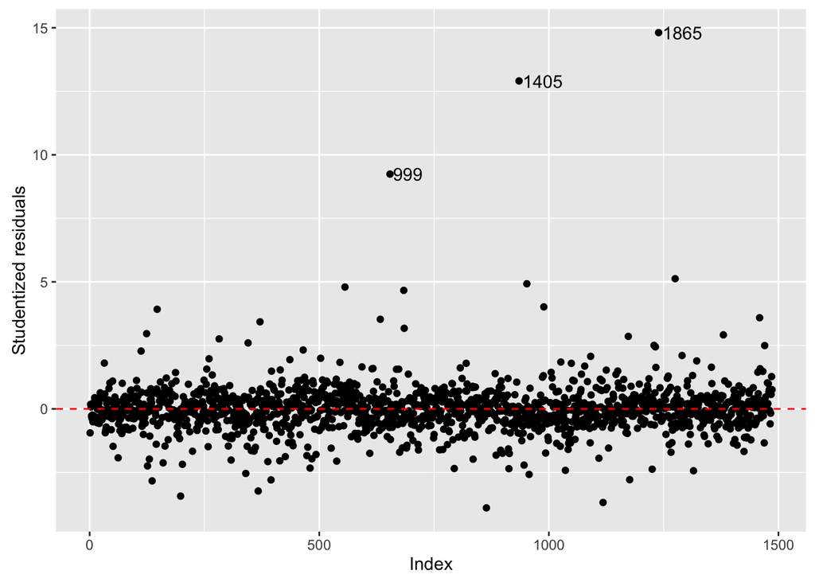

Byrjum á að sjá hvert aðlagaða skýringarhlutfallið er áður en við tökum útlagana út: 0.7910776

```r
diag1 <- fortify(stort.st)
diag1 <- diag1[diag1$.stdresid < 6.5, ]
diag1.m <- lm(nuvirdi ~ teg_eign + byggar + haednr + lyfta + ibm2 + fjhaed + fjbilast + fjsturt + fjklos + fjstof + matssvaedi + ibteg + kaup_ar, data = diag1)
summary2 <- summary(diag1.m)
```

Sjáum síðan að, þegar útlagarnir hafa verið teknir út, að aðlagaða skýringarhlutfallið er vissulega hærra, eða 0.8370989

Af summary að dæma hefur módelið batnað nokkuð, en það hlýtur að vera meir sem við getum gert. Ef við skoðum Q-Q plot sjáum við að það er afar mikil hægri slagsíða í dreifingunni (sem ætti að fylgja línunni). Við verðum að gera eitthvað í þessu ef við getum. - Hugsanlega er hægt að verpa háðu breytu módelsins á einhvern hátt til að draga úr sveigjunni á Q-Q plottinu. - Til að ákvarða hvers konar vörpun við ættum að nota er ágætt að skoða boxCox plot.

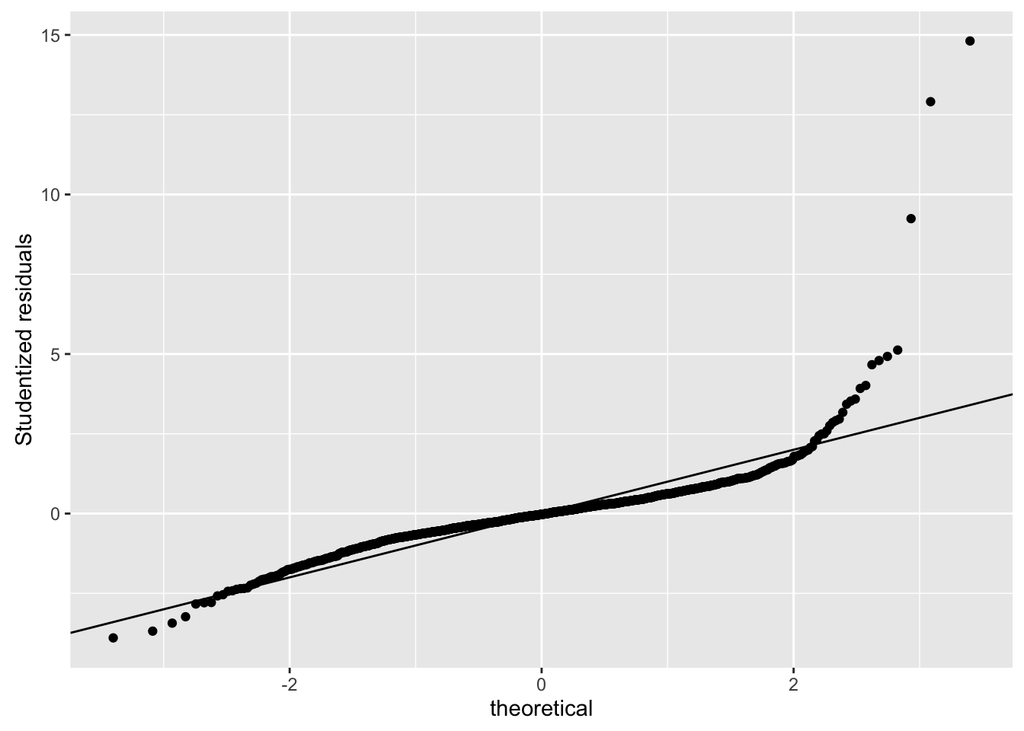

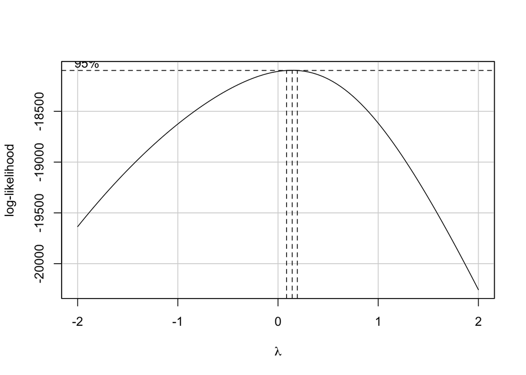

```r
fasteignir_sorted$nuvirdi <- sqrt(fasteignir_sorted$nuvirdi)
```

Í kjölfarið þurfum við að vinna með varpaða gagnasettið á sama hátt og það óvarpaða, og skoðum síðan summary af því. Í summary af módelinu getum við séð áætluð gildi allra breyta (í dálkinum estimates).

```
##
## Call:
## lm(formula = nuvirdi ~ teg_eign + byggar + haednr + lyfta + ibm2 +
##     fjhaed + fjbilast + fjbkar + fjstof + matssvaedi + ibteg +
##     kaup_ar, data = diag1)
##
## Residuals:
##     Min      1Q  Median      3Q     Max
## -65.745  -8.623  -0.354   8.049  74.797
##
## Coefficients:
##                     Estimate Std. Error t value Pr(>|t|)
## (Intercept)        278.25400   20.28748  13.716  < 2e-16 ***
## teg_eignIbudareign -13.34385    2.13665  -6.245 5.54e-10 ***
## teg_eignParhus      -2.43003    2.92744  -0.830  0.40662
## teg_eignRadhus     -10.55031    1.97705  -5.336 1.10e-07 ***
## byggarmidlungs      -0.93432    1.83384  -0.509  0.61048
## byggarlanabreyting  -8.71000    2.17570  -4.003 6.56e-05 ***
## byggarnytt          -1.18643    2.07140  -0.573  0.56689
## haednr               2.01042    0.33129   6.068 1.64e-09 ***
## lyfta1               2.89686    1.76367   1.643  0.10070
## ibm2                 0.05816    0.00158  36.817  < 2e-16 ***
## fjhaed             -11.01011    1.12612  -9.777  < 2e-16 ***
## fjbilast1            3.44926    1.38391   2.492  0.01280 *
## fjbkar               2.82225    0.99989   2.823  0.00483 **
## fjstof               2.79425    0.74116   3.770  0.00017 ***
## matssvaedi          -0.17555    0.01312 -13.384  < 2e-16 ***
## ibteg              -12.61740    1.76913  -7.132 1.55e-12 ***
## kaup_ar2012          6.43374    1.34670   4.777 1.95e-06 ***
## kaup_ar2013          9.92066    1.33772   7.416 2.04e-13 ***
## kaup_ar2014         19.62563    1.29184  15.192  < 2e-16 ***
## kaup_ar2015         28.49872    1.27654  22.325  < 2e-16 ***
## kaup_ar2016         33.96856    2.20061  15.436  < 2e-16 ***
## ---
## Signif. codes:  0 '***' 0.001 '**' 0.01 '*' 0.05 '.' 0.1 ' ' 1
##
## Residual standard error: 14.71 on 1462 degrees of freedom
## Multiple R-squared:  0.8518, Adjusted R-squared:  0.8497
## F-statistic:   420 on 20 and 1462 DF,  p-value: < 2.2e-16
```

Eins og við sjáum í summary þá fáum við umtalsvert hærra skýringarhlutfall en áður. Nú skulum við sjá hvað gerist þegar við setjum testdata gagnasettið inn í módelið og sjáum hvort að við fáum ásættanlegt skýringarhlutfall.

```r
thefinalcountdown <- predict.lm(diag1.m, newdata = testdata)
e <- testdata$nuvirdi - thefinalcountdown
RSS <- sum(e^2)
TSS <- sum((testdata$nuvirdi - mean(testdata$nuvirdi))^2)
rAdj <- 1 - ((RSS/725)/(TSS/741))
```

Skýringarhlutfallið á testdata gagnasettinu er því 0.8325881.

Af þessu má dæma að módelið standist þær kröfur sem við settum, enda er skýringarhlutfall þess sambærilegt þegar það er notað á gagnasettin tvö. Módelið má setja fram á eftirfarandi máta: